Bennett Widyolar  
ES 207 - HW #4  
3/7/2016

# Homework Assignment 4

## Objective

In this study I will examine the relationship between plant height versus breast height diameter, develop linear models to explain this relationship both by each genus and by test site, and evaluate which model is best.

## Methods

I will be using R as the programming language to analylze the data and develop linear models, and using the analysis of variance and analylsis of covariance to determine which of the models best explains the relationship.

## Data

The data for this study came from the ES 207 HW2 folder. Species name, woody stem diameter and height were collected along with longitude and latitude data. This data is ultimately to be used to estimate carbon density at each site.

## Code

The code for this project is as follows:

```r
#CLEAR VARIABLES
rm(list=ls())

#LOAD DATA
rip <- read.csv("top5_dataset.csv")
#CLEAN DATA OF NULL VALUES
rip <- rip[-c(which(rip$Woody_Height_m < 0)), ]
rip <- rip[-c(which(rip$Woody_DBH_cm < 5)), ]
#ADD HEIGHT AS CM
rip$htcm <- rip$Woody_Height_m * 100  #CONVERT TO CM

#riparian data loaded as rip
rip$projplot <- as.factor(paste(rip$ProjCode,rip$Plot.Name))

#use tapply() to cycle through each project plot and generate stats
#where ‘htcm’ is height in cm
ripsum <- data.frame(cbind(tapply(rip$htcm,rip$projplot,mean),tapply(rip$htcm,rip$projplot,sd),tapply(rip$htcm,rip$projplot,length)))

#add column names #(height mean, height standard deviation, number of plots)
colnames(ripsum) <- c("htcmmn","htcmsd","plot.n")

#add a projplot column (from row names) to ripsum
ripsum$projplot <- as.factor(rownames(ripsum))

#subset for plots with more than one measurement
ripsum <- ripsum[ripsum$plot.n > 1,]
#create proj column by stripping out the first 5 characters
ripsum$proj <- as.factor(substr(ripsum$projplot,1,5))

#create list of project sites
projlevels <- levels(ripsum$proj)

#compare a ‘for’ loop of summary
#for (p in 1:length(projlevels)) print(summary(ripsum[ripsum$proj == projlevels[p],]))
#with a summary using lapply() (known as list apply)
#print(lapply(projlevels, function(x) summary(ripsum[ripsum$proj == x,])))

#note that there are several ways of doing this task, but
#lapply() uses a list and a function to execute list items
#>> lapply(list, function(x) myfunction(x))
#here we subset using which() where we select for x in list
#and then subset again randomly using sample()
#because these row subsets are from the vectorized data.frame
#it looks like this: data[which(),][sample(),] where [rows,cols]

nsamples <- 6
ripres <- lapply(projlevels, function(x) ripsum[which(ripsum$proj == x),][sample(nrow(ripsum[which(ripsum$proj == x),]),nsamples),])

# combine samples by row using rbind()
# and by calling ripres lapply function from do.call()

ripsample <- do.call(rbind,ripres)
#summary(ripsample$proj)

#calculate CV using with(data,calc)
ripsample$cv <- with(ripsample,htcmsd / htcmmn)

#ANOVA
rip.proj.cv.aov = aov(cv~proj,data=ripsample)
print(summary(rip.proj.cv.aov))

rip.aov.hsd <- TukeyHSD(rip.proj.cv.aov)
print(rip.aov.hsd)

#ANCOVA
ripLM <- lm(formula = htcm ~ Woody_DBH_cm, data=rip)
ripLM2 <- lm(formula = htcm ~ Woody_DBH_cm + Genus, data=rip)
ripLM3 <- lm(formula = htcm ~ Woody_DBH_cm + ProjCode, data=rip)

#print(summary.lm(ripLM2))

#install.packages("HH")
#library(HH)

ancovaplot(htcm ~ Woody_DBH_cm + Genus, data=rip)
```

## Results

```
##             Df Sum Sq Mean Sq F value Pr(>F)
## proj         3 0.2841 0.09470   1.557  0.231
## Residuals   20 1.2163 0.06081
```

```
##   Tukey multiple comparisons of means
##     95% family-wise confidence level
##
## Fit: aov(formula = cv ~ proj, data = ripsample)
##
## $proj
##                    diff        lwr       upr     p adj
## HEROW-COSRP -0.02870585 -0.4272076 0.3697959 0.9970003
## NAPSO-COSRP  0.19708425 -0.2014175 0.5955860 0.5231033
## SACTO-COSRP  0.20727527 -0.1912264 0.6057770 0.4812215
## NAPSO-HEROW  0.22579010 -0.1727116 0.6242918 0.4085997
## SACTO-HEROW  0.23598112 -0.1625206 0.6344828 0.3710643
## SACTO-NAPSO  0.01019102 -0.3883107 0.4086927 0.9998637
```

Analysis of covariance results are listed below.

For the relationship: height ~ dbh

```
##
## Call:
## lm(formula = htcm ~ Woody_DBH_cm, data = rip)
##
## Residuals:
##     Min      1Q  Median      3Q     Max
## -3284.8  -258.0   -71.2   197.7  1865.9
##
## Coefficients:
##              Estimate Std. Error t value Pr(>|t|)
## (Intercept)  606.5028    10.8592   55.85   <2e-16 ***
## Woody_DBH_cm  19.9490     0.3732   53.46   <2e-16 ***
## ---
## Signif. codes:  0 '***' 0.001 '**' 0.01 '*' 0.05 '.' 0.1 ' ' 1
##
## Residual standard error: 416.6 on 2729 degrees of freedom
## Multiple R-squared:  0.5115, Adjusted R-squared:  0.5113
## F-statistic:  2858 on 1 and 2729 DF,  p-value: < 2.2e-16
```

For the relationship: height ~ dbh + Genus

```
##
## Call:
## lm(formula = htcm ~ Woody_DBH_cm + Genus, data = rip)
##
## Residuals:
##     Min      1Q  Median      3Q     Max
## -3218.9  -223.1   -36.1   196.2  2077.7
##
## Coefficients:
##              Estimate Std. Error t value Pr(>|t|)
## (Intercept)  461.3708    18.4263  25.039  < 2e-16 ***
## Woody_DBH_cm  18.3794     0.3613  50.872  < 2e-16 ***
## GenusPopulus 439.4741    22.6670  19.388  < 2e-16 ***
## GenusQuercus  60.6880    23.5804   2.574   0.0101 *
## GenusSalix    99.7009    22.3592   4.459 8.57e-06 ***
## ---
## Signif. codes:  0 '***' 0.001 '**' 0.01 '*' 0.05 '.' 0.1 ' ' 1
##
## Residual standard error: 379.2 on 2726 degrees of freedom
## Multiple R-squared:  0.5957, Adjusted R-squared:  0.5951
## F-statistic:  1004 on 4 and 2726 DF,  p-value: < 2.2e-16
```

For the relationship: height ~ dbh + Project Site

```
##
## Call:
## lm(formula = htcm ~ Woody_DBH_cm + ProjCode, data = rip)
##
## Residuals:
##     Min      1Q  Median      3Q     Max
## -3325.2  -250.6   -67.6   220.3  1961.1
##
## Coefficients:
##                Estimate Std. Error t value Pr(>|t|)
## (Intercept)    643.8692    12.1241  53.107  < 2e-16 ***
## Woody_DBH_cm    19.9622     0.3694  54.035  < 2e-16 ***
## ProjCodeHEROW -174.7121    26.9890  -6.473 1.13e-10 ***
## ProjCodeNAPSO   43.1282    32.0552   1.345    0.179
## ProjCodeSACTO -133.7237    21.1687  -6.317 3.10e-10 ***
## ---
## Signif. codes:  0 '***' 0.001 '**' 0.01 '*' 0.05 '.' 0.1 ' ' 1
##
## Residual standard error: 411 on 2726 degrees of freedom
## Multiple R-squared:  0.5251, Adjusted R-squared:  0.5244
## F-statistic: 753.5 on 4 and 2726 DF,  p-value: < 2.2e-16
```

From these we can see the model with Genus as a factor (height ~ DBH + Genus) had a better R squared value than the both the minimial adequate model (height ~ DBH) and the model with site as a factor (height ~ DBH + Project Site)

Lastly is the ANCOVA plot by Genus. (IGNORE THE OUTPUT FROM LOADING THE LIBRARY “HH”)

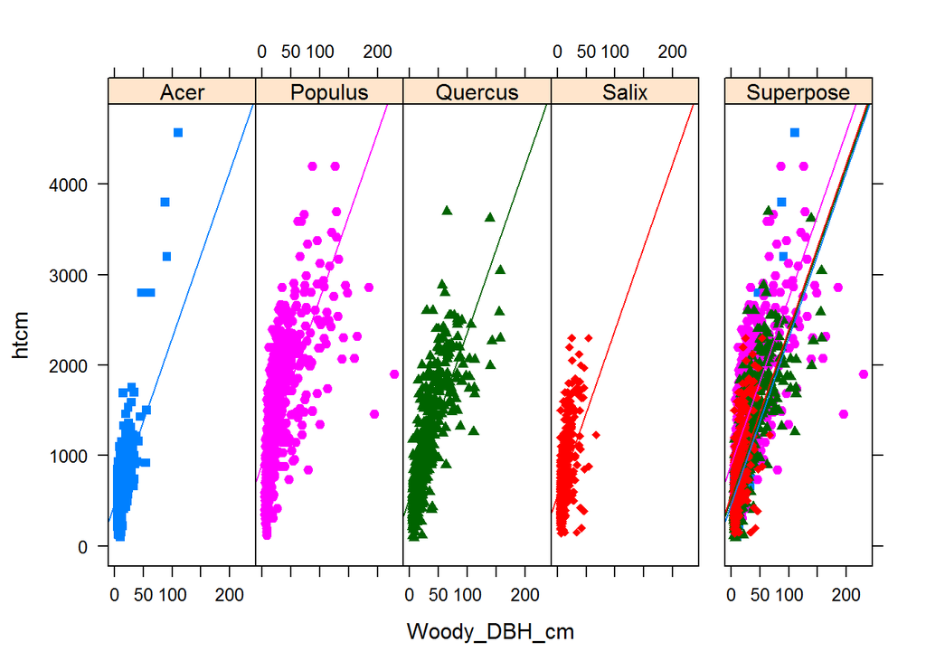

[figure not shown]

## Discussion

Based on these results, I recommend using the model of tree height vs dbh as a function of genus.